# Data 608 - Homework 1

Bruno de Melo - Spring 2022

**Principles of Data Visualization and Introduction to ggplot2**

I have provided you with data about the 5,000 fastest growing companies in the US, as compiled by Inc. magazine. lets read this in:

```r
inc <- read.csv("https://raw.githubusercontent.com/charleyferrari/CUNY_DATA_608/master/module1/Data/inc5000_data.csv", header= TRUE)
```

And lets preview this data:

```r
head(inc)
```

[output not shown]

```r
summary(inc)
```

```
      Rank          Name            Growth_Rate
 Min.   :   1   Length:5001        Min.   :  0.340
 1st Qu.:1252   Class :character   1st Qu.:  0.770
 Median :2502   Mode  :character   Median :  1.420
 Mean   :2502                      Mean   :  4.612
 3rd Qu.:3751                      3rd Qu.:  3.290
 Max.   :5000                      Max.   :421.480

    Revenue            Industry           Employees
 Min.   :2.000e+06   Length:5001        Min.   :    1.0
 1st Qu.:5.100e+06   Class :character   1st Qu.:   25.0
 Median :1.090e+07   Mode  :character   Median :   53.0
 Mean   :4.822e+07                      Mean   :  232.7
 3rd Qu.:2.860e+07                      3rd Qu.:  132.0
 Max.   :1.010e+10                      Max.   :66803.0
                                        NA's   :12
     City              State
 Length:5001        Length:5001
 Class :character   Class :character
 Mode  :character   Mode  :character
```

Think a bit on what these summaries mean. Use the space below to add some more relevant non-visual exploratory information you think helps you understand this data:

Number of companies by States

```r
# Insert your code here, create more chunks as necessary

library(tidyverse)

#Number of companies by States
inc%>%group_by(State)%>%summarise(Count=(n()))%>%arrange(desc(Count))
```

| State | Count |
| --- | --- |
| CA | 701 |
| TX | 387 |
| NY | 311 |
| VA | 283 |
| FL | 282 |
| IL | 273 |
| GA | 212 |
| OH | 186 |
| MA | 182 |
| PA | 164 |

[output cut: 42 more lines]

```r
NA
```

```r
#Aggregated revenue and number of employees by States
inc%>%group_by(State)%>%summarise(Total_Revenue_in_bn=sum(Revenue)/1000000000, No_Empl_in_k=sum(Employees/1000, na.rm = TRUE))%>%arrange(desc(Total_Revenue_in_bn))
```

[output not shown]

```r
#Revenues per employees by City
inc%>%group_by(City)%>%summarise(Total_Revenue_in_mn=sum(Revenue)/sum(Employees)/1000000, .groups = "drop_last")%>%arrange(desc(Total_Revenue_in_mn))
```

[output not shown]

```r
#Revenues by Industry
inc%>%group_by(Industry)%>%summarise(Total_Revenue_in_bn=sum(Revenue)/1000000000)%>%arrange(desc(Total_Revenue_in_bn))
```

[output not shown]

```r
#Average growth rates by Industry

inc%>%group_by(Industry)%>%summarise(Avg_Growth=mean(Growth_Rate))%>%arrange(desc(Avg_Growth))
```

[output not shown]

## Question 1

Create a graph that shows the distribution of companies in the dataset by State (ie how many are in each state). There are a lot of States, so consider which axis you should use. This visualization is ultimately going to be consumed on a ‘portrait’ oriented screen (ie taller than wide), which should further guide your layout choices.

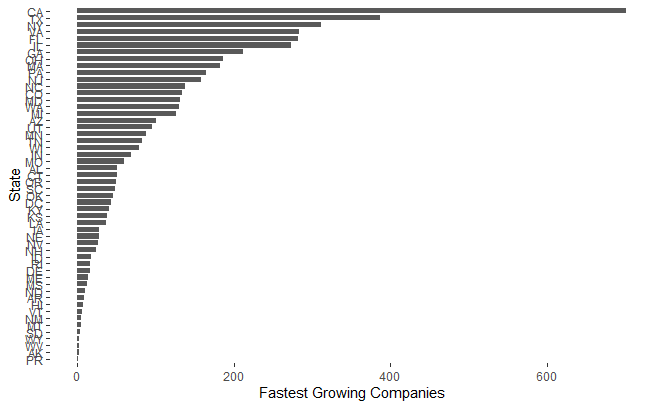

```r
# Answer Question 1 here

inc%>%group_by(State)%>%summarise(Count=n())%>%
  ggplot(aes(x=reorder(State, Count),y=Count))+
  geom_bar(stat="identity", width=.75)+
  coord_flip()+
  guides(fill="none")+
  theme(panel.background = element_blank())+
  ylab("Fastest Growing Companies") +
  xlab("State")
```

## Question 2

Lets dig in on the state with the 3rd most companies in the data set. Imagine you work for the state and are interested in how many people are employed by companies in different industries. Create a plot that shows the average and/or median employment by industry for companies in this state (only use cases with full data, use R’s `complete.cases()` function.) In addition to this, your graph should show how variable the ranges are, and you should deal with outliers.

```r
# Answer Question 2 here

inc%>%group_by(State) %>%
  summarise(Count=n()) %>%
  arrange(desc(Count)) %>%
  mutate(row_number = row_number())%>%
  filter(row_number == 3) %>%
  select(-row_number)
```

| State | Count |
| --- | --- |
| NY | 311 |

```r
NA
```

State in question is NY, hence plot will be built using NY as filter. Given outliers in some of the industries, there are two options:  
i: Build a chart using log of Employees. In this case, all large numbers are scaled down. It is a complete chart from a visual standpoint but interpretability is limited.  
ii: Build a chart with an upper limit on the X axis so that visualization is not impaired by some large numbers. Results are easier to understand but because we removed some outliers, chart does not display all numbers.

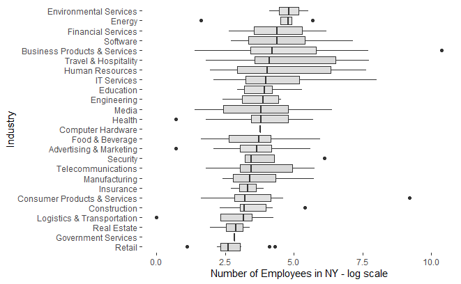

```r
# Answer Question 2 here
# Option 1

inc%>%filter(State == "NY", complete.cases(.)) %>%
   select(Industry, Employees) %>%
   mutate(LogEmployees=log(Employees))%>%
   group_by(Industry)%>%
   ggplot(aes(x=LogEmployees, y=reorder(Industry, LogEmployees, median), fill=Industry))+
   geom_boxplot()+

  scale_fill_grey(start = 0.89, end = 0.85)+
   guides(fill="none")+
   theme(panel.background = element_blank())+
   xlab("Number of Employees in NY - log scale") +
   ylab("Industry")
```

[figure not shown]

## Question 3

Now imagine you work for an investor and want to see which industries generate the most revenue per employee. Create a chart that makes this information clear. Once again, the distribution per industry should be shown.

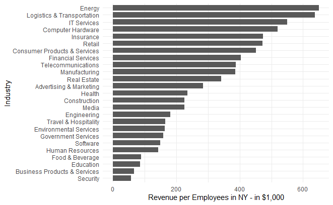

```r
# Answer Question 3 here
inc%>%filter(State == "NY", complete.cases(.)) %>%
  drop_na()%>%
  group_by(Industry)%>%
  summarise(Total_Revenue=(sum(Revenue)/1000)/sum(Employees), .groups = "drop_last")%>%
  ggplot(aes(x=reorder(Industry,Total_Revenue), y=Total_Revenue))+
  geom_bar(stat="identity", width=.75)+
  coord_flip()+
  guides(fill="none")+
  theme(panel.background = element_blank())+
  ylab("Revenue per Employees in NY - in $1,000") +
  xlab("Industry")+
  theme_minimal()
```

```r
NA
NA
```